# Análisis descriptivo, bivariado y gráficos

Ayudantía 03 · FAGOB 2026

Cristóbal Mejías · Facultad de Gobierno

Métodos Cuantitativos para la Administración Pública

abril de 2026

## ¿Qué veremos hoy?

1. Cargar los datos procesados en la AY-2
2. Tablas de frecuencia
3. Estadísticos descriptivos por grupo
4. Tablas listas para reportar en una línea
5. Gráficos con `ggplot2`
6. Práctica autónoma

Al final de la sesión sabrás generar tablas y gráficos listos para un informe.

# Punto de partida

## ¿Qué hicimos en la AY-2?

- Seleccionamos y renombramos variables con `select()`
- Recodificamos con `mutate()` + `factor()`
- Convertimos -88 y -99 en `NA`
- Creamos tramos con `case_when()` e `if_else()`
- Guardamos la base con `saveRDS()`

**Hoy retomamos desde ahí:** describir, cruzar y visualizar.

## Paquetes y datos

```r
pacman::p_load(
  tidyverse,   # manipulación de datos y gráficos (dplyr, ggplot2)
  janitor,     # tablas cruzadas rápidas (tabyl)
  gt,          # tablas con formato para informes
  gtsummary,   # tablas descriptivas en una línea
  sjmisc       # frecuencias rápidas (frq)
)
```

```r
# Opción 1: desde tu carpeta output/
casen_proc <- readRDS("output/casen_proc.rds")

# Opción 2: desde GitHub
casen_proc <- readRDS(gzcon(url("https://github.com/Cristobal-Mejias-G/metodos-cuantitativos-fagob/raw/main/datos/casen_proc.rds")))
```

# Tablas de frecuencia

## La lógica: procesar → formatear

| Paso | Herramienta | ¿Para qué? |
| --- | --- | --- |
| 1. Procesar | `dplyr` | Calcular frecuencias, medias, porcentajes |
| 2. Formatear | `gt` | Título, nombres de columnas, separador de miles, fuente |

## Paso 1: procesar con `count()`

```r
tab_pobreza <- casen_proc |>
  count(pobreza) |>
  mutate(porcentaje = n / sum(n) * 100)

tab_pobreza
```

```
# A tibble: 4 × 3
  pobreza                      n porcentaje
  <fct>                    <int>      <dbl>
1 Pobreza severa              33       2.18
2 Pobreza por ingresos        83       5.49
3 Pobreza multidimensional   152      10.1
4 No pobre                  1243      82.3
```

`count()` resume en una línea lo que antes hacíamos con `group_by()` + `summarise(n = n())`.

## Paso 2: formatear con `gt`

```r
tab_pobreza |>
  gt() |>
  cols_label(
    pobreza    = "Situación de pobreza",
    n          = "N",
    porcentaje = "%"
  ) |>
  fmt_number(porcentaje, decimals = 1,
             dec_mark = ",") |>
  tab_header("Distribución por situación de pobreza") |>
  tab_source_note("Fuente: elaboración propia en base a CASEN 2024.")
```

Distribución por situación de pobreza

| Situación de pobreza | N | % |
| --- | --- | --- |
| Pobreza severa | 33 | 2,2 |
| Pobreza por ingresos | 83 | 5,5 |
| Pobreza multidimensional | 152 | 10,1 |
| No pobre | 1243 | 82,3 |

Fuente: elaboración propia en base a CASEN 2024.

## Tablas cruzadas: `janitor::tabyl()`

```r
casen_proc |>
  tabyl(pobreza, sexo) |>
  adorn_totals("row") |>
  adorn_percentages("col") |>
  adorn_pct_formatting(digits = 1) |>
  adorn_ns()
```

```
                  pobreza       Hombre        Mujer
           Pobreza severa   2.0%  (17)   2.4%  (16)
     Pobreza por ingresos   5.0%  (42)   6.1%  (41)
 Pobreza multidimensional  10.3%  (86)   9.8%  (66)
                 No pobre  82.7% (694)  81.7% (549)
                    Total 100.0% (839) 100.0% (672)
```

Cada `adorn_*()` agrega una capa: totales, porcentajes por columna, formato y los N entre paréntesis.

# Descriptivos por grupo

## Variable numérica según una categórica

```r
tab_ingreso <- casen_proc |>
  group_by(sexo) |>
  summarise(
    n       = n(),
    media   = mean(ingreso, na.rm = TRUE),
    de      = sd(ingreso, na.rm = TRUE),
    mediana = median(ingreso, na.rm = TRUE)
  )
```

```r
tab_ingreso |>
  gt() |>
  cols_label(sexo = "Sexo", n = "N", media = "Media", de = "DE", mediana = "Mediana") |>
  fmt_number(c(media, de, mediana), decimals = 0, sep_mark = ".") |>
  tab_header("Ingreso laboral según sexo")
```

Ingreso laboral según sexo

| Sexo | N | Media | DE | Mediana |
| --- | --- | --- | --- | --- |
| Hombre | 839 | 927.848 | 900.966 | 630.000 |
| Mujer | 672 | 732.491 | 621.797 | 550.000 |

## El mismo patrón con otra agrupación

```r
casen_proc |>
  group_by(tramo_edad) |>
  summarise(
    n       = n(),
    media   = mean(ingreso, na.rm = TRUE),
    mediana = median(ingreso, na.rm = TRUE)
  ) |>
  gt() |>
  fmt_number(c(media, mediana),
             decimals = 0, sep_mark = ".") |>
  tab_header("Ingreso laboral según tramo etario")
```

Ingreso laboral según tramo etario

| tramo_edad | n | media | mediana |
| --- | --- | --- | --- |
| Menor de edad | 1 | 120.000 | 120.000 |
| Adulto joven | 675 | 802.667 | 600.000 |
| Adulto | 661 | 913.713 | 600.000 |
| Adulto mayor | 174 | 717.322 | 530.000 |

## Tablas listas en una línea: `gtsummary`

```r
theme_gtsummary_language("es",
                         big.mark = ".",
                         decimal.mark = ",")

casen_proc |>
  select(sexo, edad, ingreso,
         tramo_edad) |>
  tbl_summary(by = sexo)
```

| **Característica** | **Hombre** N = 839<sup>1</sup> | **Mujer** N = 672<sup>1</sup> |
| --- | --- | --- |
| Edad | 42 (32 – 54) | 41 (31 – 52) |
| Ingreso ocupación principal corregido | 630.000 (500.000 – 1.000.000) | 550.000 (460.000 – 800.000) |
| tramo_edad |  |  |
| Menor de edad | 0 (0%) | 1 (0,1%) |
| Adulto joven | 362 (43%) | 313 (47%) |
| Adulto | 365 (44%) | 296 (44%) |
| Adulto mayor | 112 (13%) | 62 (9,2%) |

<sup>1</sup> Mediana (Q1 – Q3); n (%)

Detecta solo si cada variable es categórica (N y %) o numérica (mediana y rango intercuartílico).

# Gráficos con `ggplot2`

## La lógica de `ggplot2`: capas

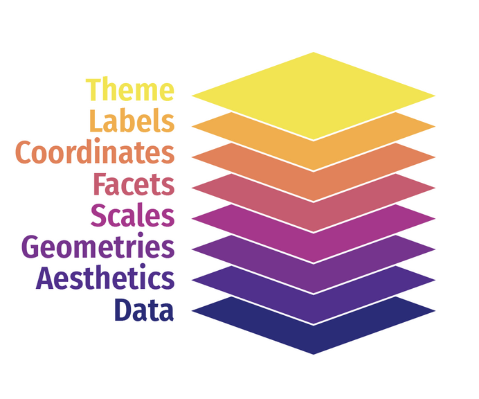

| Capa | Función | ¿Para qué? |
| --- | --- | --- |
| 1. Datos y ejes | `ggplot(datos, aes(...))` | El lienzo |
| 2. Geometría | `geom_*()` | La forma: barras, puntos, cajas |
| 3. Etiquetas | `labs()` | Títulos, ejes, leyenda |
| 4. Estética | `theme_*()`, `scale_*()` | El estilo visual |

## Barras: frecuencia de una variable

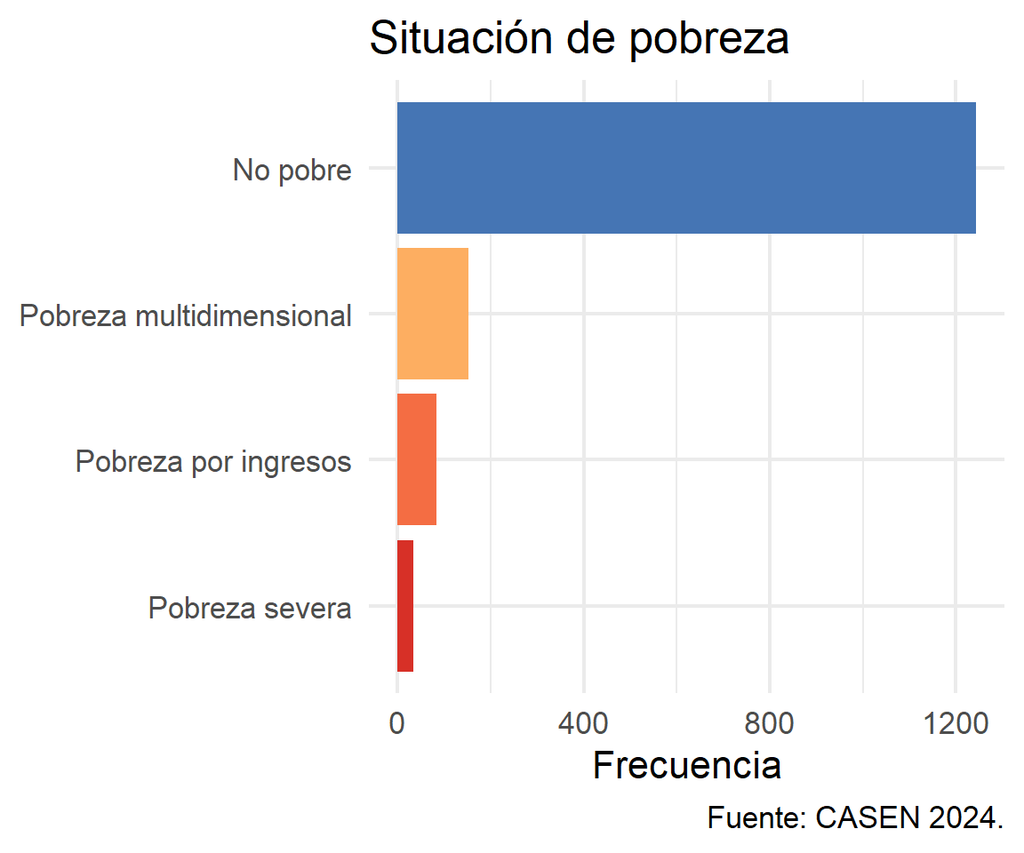

```r
ggplot(casen_proc,
       aes(x = pobreza, fill = pobreza)) +
  geom_bar() +
  scale_fill_manual(values = c(
    "#d73027", "#f46d43", "#fdae61", "#4575b4"
  )) +
  labs(
    title   = "Situación de pobreza",
    x       = NULL,
    y       = "Frecuencia",
    caption = "Fuente: CASEN 2024."
  ) +
  theme(legend.position = "none") +
  coord_flip()
```

## Barras agrupadas: dos variables categóricas

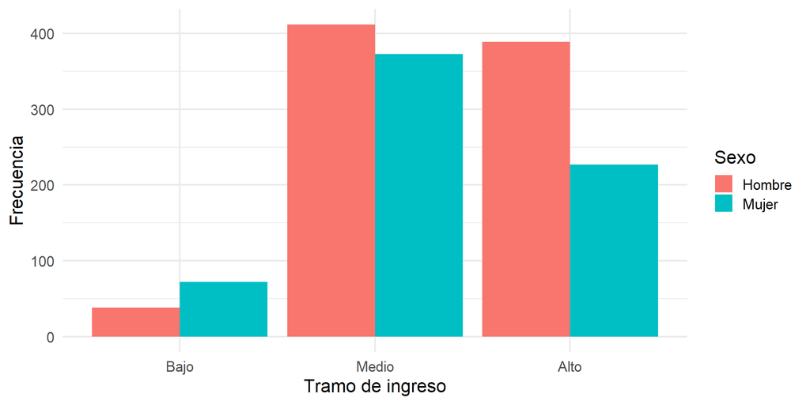

```r
ggplot(casen_proc,
       aes(x = tramo_ingreso, fill = sexo)) +
  geom_bar(position = "dodge") +
  labs(x = "Tramo de ingreso",
       y = "Frecuencia", fill = "Sexo")
```

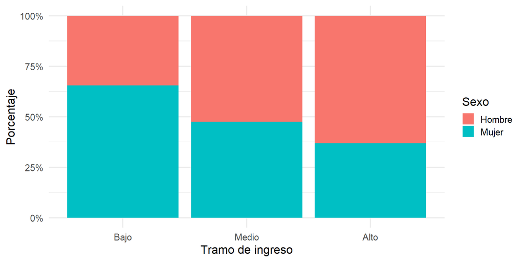

```r
ggplot(casen_proc,
       aes(x = tramo_ingreso, fill = sexo)) +
  geom_bar(position = "fill") +
  scale_y_continuous(labels = scales::label_percent()) +
  labs(x = "Tramo de ingreso",
       y = "Porcentaje", fill = "Sexo")
```

`"dodge"` pone las barras lado a lado; `"fill"` las apila al 100%, útil para comparar proporciones.

## Boxplot: variable continua por grupo

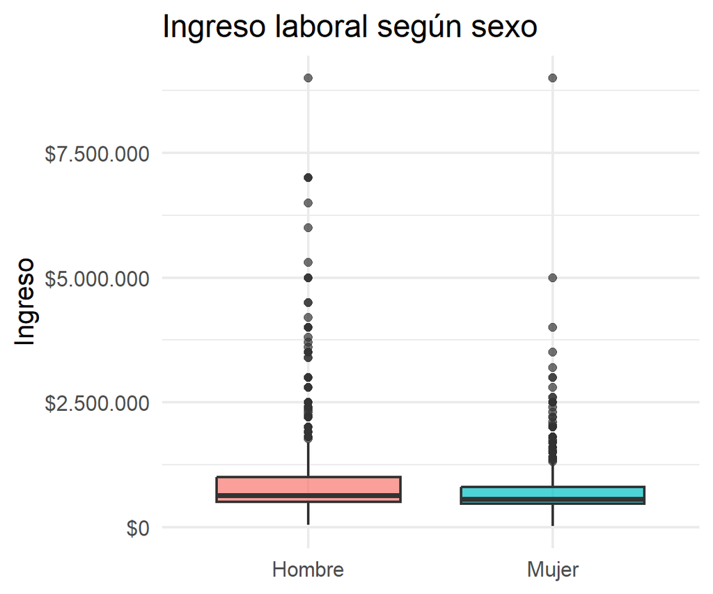

```r
casen_proc |>
  drop_na(ingreso) |>
  ggplot(aes(x = sexo, y = ingreso,
             fill = sexo)) +
  geom_boxplot(alpha = 0.7) +
  scale_y_continuous(
    labels = scales::label_dollar(big.mark = ".")
  ) +
  labs(title = "Ingreso laboral según sexo",
       x = NULL, y = "Ingreso") +
  theme(legend.position = "none")
```

## Dispersión con línea de tendencia

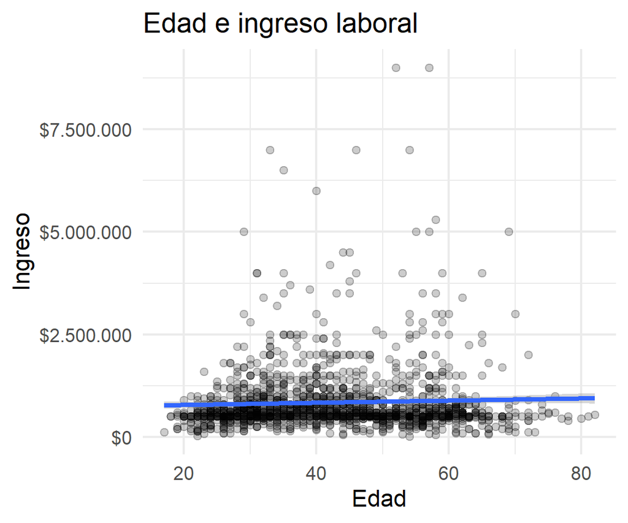

```r
casen_proc |>
  drop_na(ingreso) |>
  ggplot(aes(x = edad, y = ingreso)) +
  geom_point(alpha = 0.2) +
  geom_smooth(method = "lm") +
  scale_y_continuous(
    labels = scales::label_dollar(big.mark = ".")
  ) +
  labs(title = "Edad e ingreso laboral",
       x = "Edad", y = "Ingreso")
```

`geom_smooth(method = "lm")` agrega la recta de regresión con su intervalo de confianza al 95%.

## Para seguir aprendiendo

- [R for Data Science (2e): visualización](https://r4ds.hadley.nz/data-visualize.html)
- [Documentación de ggplot2](https://ggplot2.tidyverse.org/)
- [Documentación de gt](https://gt.rstudio.com/) y [gtsummary](https://www.danieldsjoberg.com/gtsummary/)

# Práctica autónoma

## Tu turno (10 min)

Con `casen_proc`, trabaja con **`actividad`**, **`tramo_edad`** e **`ingreso_pc`**.

1. Tabla de frecuencias de `actividad` con `count()` + `gt()`: N, porcentaje, título y fuente
2. Tabla de `ingreso_pc` por `tramo_edad`: n, media, desviación estándar y mediana
3. Boxplot de `ingreso_pc` según `actividad`
4. Extra: compara tus tablas con `tbl_summary(by = actividad)`

## Resumen de la sesión

| Tarea | Función(es) |
| --- | --- |
| Frecuencias | `count()` + `mutate()` |
| Tablas cruzadas | `tabyl()` + `adorn_*()` |
| Descriptivos por grupo | `group_by()` + `summarise()` |
| Formato para informe | `gt()`, `fmt_number()`, `tab_header()` |
| Tabla descriptiva rápida | `tbl_summary()` |
| Barras / boxplot / dispersión | `geom_bar()`, `geom_boxplot()`, `geom_point()` + `geom_smooth()` |

# ¡Nos vemos en la siguiente sesión!